# Modul 06 - Classification

Roni Yunis

17/09/2024

# Pengantar

Analisis Prediktif bisa menggunakan dua metode yaitu;

1. Classification: suatu bentuk dasar dari analisis data dimana datanya diklasifikasi ke dalam kelas-kelas.
2. Regression: memprediksi nilai variabel numerik, misalnya angka pendapatan perusahaan atau angka penjualan.

Untuk mendukung kedua hal tersebut, maka diperlukan **Machine Learning (ML)**, ML adalah tentang bagaimana membuat komputer belajar dan melakukan tugas dengan lebih baik berdasarkan data historis masa lalu. Pembelajaran selalu dilakukan berdasarkan pada observasi dari data yang tersedia. Ada dua jenis ML.

1. Supervised Learning: yaitu mesin membuat model prediktif dengan bantuan sekumpulan data pelatihan (data training) atau sering disebut juga pembelajaran dengan pengawasan, karena variabel yang digunakan sudah ditentukan
2. Unsupervised Learning: yaitu model prediktif yang tidak menggunakan data pelatihan (data training), tidak ada variabel target, sehingga sering disebut dengan pembelajaran tanpa pengawasan, karena variabel yang digunakan tidak ditentukan.

Untuk menghasilkan model prediksi yang baik, sehingga dataset bisa dibagi menjadi 3 bagian, yaitu:

1. **Training Data Partition**: Partisi data pelatihan (data training) digunakan untuk melatih model. Rincian variabel hasil sudah diketahui. Untuk masalah klasifikasi, kelas variabel hasil sudah ditentukan dan terkadang dibuat secara manual dengan campur tangan manusia.
2. **Test Data Partitions**: Partisi data pengujian (data testing) adalah bagian dari kumpulan data yang tidak ada dalam kumpulan pelatihan. Ini digunakan untuk menilai kinerja model untuk data baru. Partisi ini terkadang disebut partisi testing. Model harus bekerja dengan baik untuk data set pelatihan dan data pengujian.
3. **Validation Data Partition**: Partisi data validasi digunakan untuk menyempurnakan kinerja model dan mengurangi masalah overfitting. Partisi ini dapat digunakan untuk menilai beberapa model dan memilih model terbaik. Kumpulan data ini tidak digunakan untuk membangun model. Jadi, model tersebut belum pernah melihat kumpulan data ini sebelumnya. Ini membantu menyempurnakan kinerja model dan mengurangi overfitting.

**Overfitting** adalah suatu keadaan dimana data yang digunakan untuk pelatihan itu adalah yang terbaik. Sehingga apabila dilakukan tes dengan menggunakan data yang berbeda dapat mengurangi akurasi (wikipedia)

# Load Packages

Untuk mendukung klasifikasi yang akan dilakukan, maka ada beberapa packages/library yang diperlukan.

```r
# Package untuk manipulasi data
library(dplyr)
```

```r
# Package untuk visualisasi data
library (ggplot2)
# package untuk praktisi data
library(caret)
# package untuk klasifikasi
library(randomForest)
# package untuk mengukur perfomansi model klasifikasi
library(e1071)
# package untuk menguji kehandalan dari model prediksi
library(ROCit)
# package untuk decision tree
library(rpart)
# pakage untuk memodelkan pohon keputusan
library(rpart.plot)
```

# Data Preparation

Import data dan melihat struktur data

```r
credit <- read.csv("data/credit.csv")
glimpse(credit)
```

```
## Rows: 1,000
## Columns: 21
## $ checking_balance     <chr> "< 0 DM", "1 - 200 DM", "unknown", "< 0 DM", "< 0…
## $ months_loan_duration <int> 6, 48, 12, 42, 24, 36, 24, 36, 12, 30, 12, 48, 12…
## $ credit_history       <chr> "critical", "repaid", "critical", "repaid", "dela…
## $ purpose              <chr> "radio/tv", "radio/tv", "education", "furniture",…
## $ amount               <int> 1169, 5951, 2096, 7882, 4870, 9055, 2835, 6948, 3…
## $ savings_balance      <chr> "unknown", "< 100 DM", "< 100 DM", "< 100 DM", "<…
## $ employment_length    <chr> "> 7 yrs", "1 - 4 yrs", "4 - 7 yrs", "4 - 7 yrs",…
## $ installment_rate     <int> 4, 2, 2, 2, 3, 2, 3, 2, 2, 4, 3, 3, 1, 4, 2, 4, 4…
## $ personal_status      <chr> "single male", "female", "single male", "single m…
## $ other_debtors        <chr> "none", "none", "none", "guarantor", "none", "non…
## $ residence_history    <int> 4, 2, 3, 4, 4, 4, 4, 2, 4, 2, 1, 4, 1, 4, 4, 2, 4…
## $ property             <chr> "real estate", "real estate", "real estate", "bui…
## $ age                  <int> 67, 22, 49, 45, 53, 35, 53, 35, 61, 28, 25, 24, 2…
## $ installment_plan     <chr> "none", "none", "none", "none", "none", "none", "…
## $ housing              <chr> "own", "own", "own", "for free", "for free", "for…
## $ existing_credits     <int> 2, 1, 1, 1, 2, 1, 1, 1, 1, 2, 1, 1, 1, 2, 1, 1, 2…
## $ default              <int> 1, 2, 1, 1, 2, 1, 1, 1, 1, 2, 2, 2, 1, 2, 1, 2, 1…
## $ dependents           <int> 1, 1, 2, 2, 2, 2, 1, 1, 1, 1, 1, 1, 1, 1, 1, 1, 1…
## $ telephone            <chr> "yes", "none", "none", "none", "none", "yes", "no…
## $ foreign_worker       <chr> "yes", "yes", "yes", "yes", "yes", "yes", "yes", …
## $ job                  <chr> "skilled employee", "skilled employee", "unskille…
```

Melihat ringkasan dari data

```r
summary(credit)
```

```
##  checking_balance   months_loan_duration credit_history       purpose
##  Length:1000        Min.   : 4.0         Length:1000        Length:1000
##  Class :character   1st Qu.:12.0         Class :character   Class :character
##  Mode  :character   Median :18.0         Mode  :character   Mode  :character
##                     Mean   :20.9
##                     3rd Qu.:24.0
##                     Max.   :72.0
##      amount      savings_balance    employment_length  installment_rate
##  Min.   :  250   Length:1000        Length:1000        Min.   :1.000
##  1st Qu.: 1366   Class :character   Class :character   1st Qu.:2.000
##  Median : 2320   Mode  :character   Mode  :character   Median :3.000
##  Mean   : 3271                                         Mean   :2.973
##  3rd Qu.: 3972                                         3rd Qu.:4.000
##  Max.   :18424                                         Max.   :4.000
##  personal_status    other_debtors      residence_history   property
##  Length:1000        Length:1000        Min.   :1.000     Length:1000
##  Class :character   Class :character   1st Qu.:2.000     Class :character
##  Mode  :character   Mode  :character   Median :3.000     Mode  :character
##                                        Mean   :2.845
##                                        3rd Qu.:4.000
##                                        Max.   :4.000
##       age        installment_plan     housing          existing_credits
##  Min.   :19.00   Length:1000        Length:1000        Min.   :1.000
##  1st Qu.:27.00   Class :character   Class :character   1st Qu.:1.000
##  Median :33.00   Mode  :character   Mode  :character   Median :1.000
##  Mean   :35.55                                         Mean   :1.407
##  3rd Qu.:42.00                                         3rd Qu.:2.000
##  Max.   :75.00                                         Max.   :4.000
##     default      dependents     telephone         foreign_worker
##  Min.   :1.0   Min.   :1.000   Length:1000        Length:1000
##  1st Qu.:1.0   1st Qu.:1.000   Class :character   Class :character
##  Median :1.0   Median :1.000   Mode  :character   Mode  :character
##  Mean   :1.3   Mean   :1.155
##  3rd Qu.:2.0   3rd Qu.:1.000
##  Max.   :2.0   Max.   :2.000
##      job
##  Length:1000
##  Class :character
##  Mode  :character
##
##
##
```

Melihat 6 baris teratas dari data credit

```r
head(credit)
```

|  | checking_balance | months_loan_duration | credit_history | purpose | amount | savings_balance | employment_length | installment_rate | personal_status | other_debtors | residence_history | property | age | installment_plan | housing | existing_credits | default | dependents | telephone | foreign_worker | job |
| --- | --- | --- | --- | --- | --- | --- | --- | --- | --- | --- | --- | --- | --- | --- | --- | --- | --- | --- | --- | --- | --- |
| 1 | < 0 DM | 6 | critical | radio/tv | 1169 | unknown | > 7 yrs | 4 | single male | none | 4 | real estate | 67 | none | own | 2 | 1 | 1 | yes | yes | skilled employee |
| 2 | 1 - 200 DM | 48 | repaid | radio/tv | 5951 | < 100 DM | 1 - 4 yrs | 2 | female | none | 2 | real estate | 22 | none | own | 1 | 2 | 1 | none | yes | skilled employee |
| 3 | unknown | 12 | critical | education | 2096 | < 100 DM | 4 - 7 yrs | 2 | single male | none | 3 | real estate | 49 | none | own | 1 | 1 | 2 | none | yes | unskilled resident |
| 4 | < 0 DM | 42 | repaid | furniture | 7882 | < 100 DM | 4 - 7 yrs | 2 | single male | guarantor | 4 | building society savings | 45 | none | for free | 1 | 1 | 2 | none | yes | skilled employee |
| 5 | < 0 DM | 24 | delayed | car (new) | 4870 | < 100 DM | 1 - 4 yrs | 3 | single male | none | 4 | unknown/none | 53 | none | for free | 2 | 2 | 2 | none | yes | skilled employee |
| 6 | unknown | 36 | repaid | education | 9055 | unknown | 1 - 4 yrs | 2 | single male | none | 4 | unknown/none | 35 | none | for free | 1 | 1 | 2 | yes | yes | unskilled resident |

Melihat 6 baris terakhir dari data credit

```r
tail(credit)
```

|  | checking_balance | months_loan_duration | credit_history | purpose | amount | savings_balance | employment_length | installment_rate | personal_status | other_debtors | residence_history | property | age | installment_plan | housing | existing_credits | default | dependents | telephone | foreign_worker | job |
| --- | --- | --- | --- | --- | --- | --- | --- | --- | --- | --- | --- | --- | --- | --- | --- | --- | --- | --- | --- | --- | --- |
| 995 | unknown | 12 | repaid | car (new) | 2390 | unknown | > 7 yrs | 4 | single male | none | 3 | other | 50 | none | own | 1 | 1 | 1 | yes | yes | skilled employee |
| 996 | unknown | 12 | repaid | furniture | 1736 | < 100 DM | 4 - 7 yrs | 3 | female | none | 4 | real estate | 31 | none | own | 1 | 1 | 1 | none | yes | unskilled resident |
| 997 | < 0 DM | 30 | repaid | car (used) | 3857 | < 100 DM | 1 - 4 yrs | 4 | divorced male | none | 4 | building society savings | 40 | none | own | 1 | 1 | 1 | yes | yes | mangement self-employed |
| 998 | unknown | 12 | repaid | radio/tv | 804 | < 100 DM | > 7 yrs | 4 | single male | none | 4 | other | 38 | none | own | 1 | 1 | 1 | none | yes | skilled employee |
| 999 | < 0 DM | 45 | repaid | radio/tv | 1845 | < 100 DM | 1 - 4 yrs | 4 | single male | none | 4 | unknown/none | 23 | none | for free | 1 | 2 | 1 | yes | yes | skilled employee |
| 1000 | 1 - 200 DM | 45 | critical | car (used) | 4576 | 101 - 500 DM | unemployed | 3 | single male | none | 4 | other | 27 | none | own | 1 | 1 | 1 | none | yes | skilled employee |

Kalau kita lihat ada beberapa variabel yang type datanya kategorical, yaitu variabel `checking_balance`, `saving_balance`, `employment_length`, `personal_status`, `other_debtors`, `property`, `installment_plan`, `housing`, `telephone`, `foreign_worker`, `credit_history`, `purpose`, dan `job`

# EDA dan Visualisasi

Melihat data kosong atau missing value (NA’s)

```r
colSums(is.na(credit))
```

```
##     checking_balance months_loan_duration       credit_history
##                    0                    0                    0
##              purpose               amount      savings_balance
##                    0                    0                    0
##    employment_length     installment_rate      personal_status
##                    0                    0                    0
##        other_debtors    residence_history             property
##                    0                    0                    0
##                  age     installment_plan              housing
##                    0                    0                    0
##     existing_credits              default           dependents
##                    0                    0                    0
##            telephone       foreign_worker                  job
##                    0                    0                    0
```

Bisa dilihat bahwa tidak ada data kosong atau NA’s

Kita lanjutkan melihat kategorikal dari beberapa variabel`

```r
# melihat kategori dari checking_balance
table(credit$checking_balance)
```

```
##
##     < 0 DM   > 200 DM 1 - 200 DM    unknown
##        274         63        269        394
```

Bisa dilihat ada 4 kategori, yaitu <0, 1-200, >200, dan unknown

```r
# melihat kategori dari savings_balance
table(credit$savings_balance)
```

```
##
##      < 100 DM     > 1000 DM  101 - 500 DM 501 - 1000 DM       unknown
##           603            48           103            63           183
```

Bisa dilihat ada 5 kategori, <100, 101-500, 501-100, >1000, dan unknown

```r
# melihat kategori dari housing
table(credit$housing)
```

```
##
## for free      own     rent
##      108      713      179
```

Ternyata housing terbanyak adalah untuk kategori own

```r
# Melihat proporsi dari kategori housing
prop.table(table(credit$housing))
```

```
##
## for free      own     rent
##    0.108    0.713    0.179
```

```r
# melihat kategori dari property
table(credit$property)
```

```
##
## building society savings                    other              real estate
##                      232                      332                      282
##             unknown/none
##                      154
```

```r
# Melihat kategori dari month_loan_duration dan purpose
table(credit$months_loan_duration, credit$purpose)
```

```
##
##      business car (new) car (used) domestic appliances education furniture
##   4         0         3          0                   0         0         1
##   5         1         0          0                   0         0         0
##   6         2        25          2                   2         5        11
##   7         0         0          0                   0         0         0
##   8         1         2          0                   0         0         1
##   9         2        11          1                   1         6        10
##   10        0        13          2                   1         1         6
##   11        1         5          0                   0         0         1
##   12        9        49         10                   2        10        35
##   13        1         0          0                   0         0         0
##   14        1         3          0                   0         0         0
##   15        3        13          7                   3         4        12
##   16        0         2          0                   0         0         0
```

[output cut: 55 more lines]

```r
# melihat kategori purpose
table(credit$purpose)
```

```
##
##            business           car (new)          car (used) domestic appliances
##                  97                 234                 103                  12
##           education           furniture              others            radio/tv
##                  50                 181                  12                 280
##             repairs          retraining
##                  22                   9
```

Bisa dilihat ada 10 kategori. Kategori yang paling banyak adalah radio/tv

```r
# melihat kategori dari foreign worker
table(credit$foreign_worker)
```

```
##
##  no yes
##  37 963
```

Ternyata kategori untuk pekerja asing yang paling banyak yaitu sebanyak 963

*Latihan* Berapa banyak foreign_worker yang mengujukan credit (purpose) untuk Radio/TV?

```r
# Your Code
```

```r
# melihat kategori credit_history
table(credit$credit_history)
```

```
##
##               critical                delayed           fully repaid
##                    293                     88                     40
## fully repaid this bank                 repaid
##                     49                    530
```

Kategori credit history yang paling banyak adalah repaid.

```r
# melihat asosiasi antara purpose dan credit history
table(credit$purpose, credit$credit_history)
```

```
##
##                       critical delayed fully repaid fully repaid this bank
##   business                  19      23           15                      7
##   car (new)                 78      17            7                     12
##   car (used)                36       8            3                      5
##   domestic appliances        1       0            0                      1
##   education                 19       5            0                      3
##   furniture                 50      10            7                      8
##   others                     3       2            1                      2
##   radio/tv                  80      20            4                      9
##   repairs                    6       3            2                      0
##   retraining                 1       0            1                      2
##
##                       repaid
##   business                33
##   car (new)              120
##   car (used)              51
##   domestic appliances     10
##   education               23
##   furniture              106
##   others                   4
##   radio/tv               167
##   repairs                 11
##   retraining               5
```

Ternyata bisa dilihat bahwa repaid dan untuk tujuan radio/tv adalah yang paling banyak yaitu sebanyak 167

*Latihan* Lihatkan kategori dari variabel yang belum dijelaskan sebelumnya.

```r
# your code
```

kita akan filter, credit purpose = “radio/tv”

```r
radiotv <- filter(credit, purpose == "radio/tv")
head(radiotv)
```

|  | checking_balance | months_loan_duration | credit_history | purpose | amount | savings_balance | employment_length | installment_rate | personal_status | other_debtors | residence_history | property | age | installment_plan | housing | existing_credits | default | dependents | telephone | foreign_worker | job |
| --- | --- | --- | --- | --- | --- | --- | --- | --- | --- | --- | --- | --- | --- | --- | --- | --- | --- | --- | --- | --- | --- |
| 1 | < 0 DM | 6 | critical | radio/tv | 1169 | unknown | > 7 yrs | 4 | single male | none | 4 | real estate | 67 | none | own | 2 | 1 | 1 | yes | yes | skilled employee |
| 2 | 1 - 200 DM | 48 | repaid | radio/tv | 5951 | < 100 DM | 1 - 4 yrs | 2 | female | none | 2 | real estate | 22 | none | own | 1 | 2 | 1 | none | yes | skilled employee |
| 3 | unknown | 12 | repaid | radio/tv | 3059 | > 1000 DM | 4 - 7 yrs | 2 | divorced male | none | 4 | real estate | 61 | none | own | 1 | 1 | 1 | none | yes | unskilled resident |
| 4 | 1 - 200 DM | 12 | repaid | radio/tv | 1567 | < 100 DM | 1 - 4 yrs | 1 | female | none | 1 | other | 22 | none | own | 1 | 1 | 1 | yes | yes | skilled employee |
| 5 | < 0 DM | 24 | repaid | radio/tv | 1282 | 101 - 500 DM | 1 - 4 yrs | 4 | female | none | 2 | other | 32 | none | own | 1 | 2 | 1 | none | yes | unskilled resident |
| 6 | unknown | 24 | critical | radio/tv | 2424 | unknown | > 7 yrs | 4 | single male | none | 4 | building society savings | 53 | none | own | 2 | 1 | 1 | none | yes | skilled employee |

Kita akan melihat berapa banyak pekerja asing yang mengajukan credit utk tujuan radio/tv

```r
# Melihat berapa banyak pekerja asing yang mengajukan kredit untuk radio/tv
radiotv %>%
  group_by(foreign_worker) %>%
  count() %>%
  arrange(-n)
```

| foreign_worker | n |
| --- | --- |
| yes | 275 |
| no | 5 |

Bisa kita lihat bahwa pekerja asing dengan tujuan credit utk radio/tv ada sebanyak 275

Sekarang kita akan melihat berapa jumlah pengajuan credit dilihat dari jenis pekerjaan (job)

```r
radiotv %>%
  group_by(job) %>%
  count() %>%
  arrange(-n)
```

| job | n |
| --- | --- |
| skilled employee | 195 |
| unskilled resident | 57 |
| mangement self-employed | 26 |
| unemployed non-resident | 2 |

Jenis pekerjaan yang paling banyak mengajukan credit utk radio/tv adalah *skilled employee*

```r
radiotv %>%
  group_by(personal_status) %>%
  count() %>%
  arrange(n)
```

| personal_status | n |
| --- | --- |
| divorced male | 7 |
| married male | 42 |
| female | 85 |
| single male | 146 |

Jumlah pekerja dengan status *single male* ada sebanyak 146 orang

Kita akan melihat hubungan antara jenis pekerjaan dengan personal status

```r
table(radiotv$job, radiotv$personal_status)
```

```
##
##                           divorced male female married male single male
##   mangement self-employed             1      6            2          17
##   skilled employee                    5     58           29         103
##   unemployed non-resident             0      2            0           0
##   unskilled resident                  1     19           11          26
```

Bisa dilihat bahwa jenis pekerjaan *skill employee* dengan status *single male* yang paling banyak yaitu 103 orang

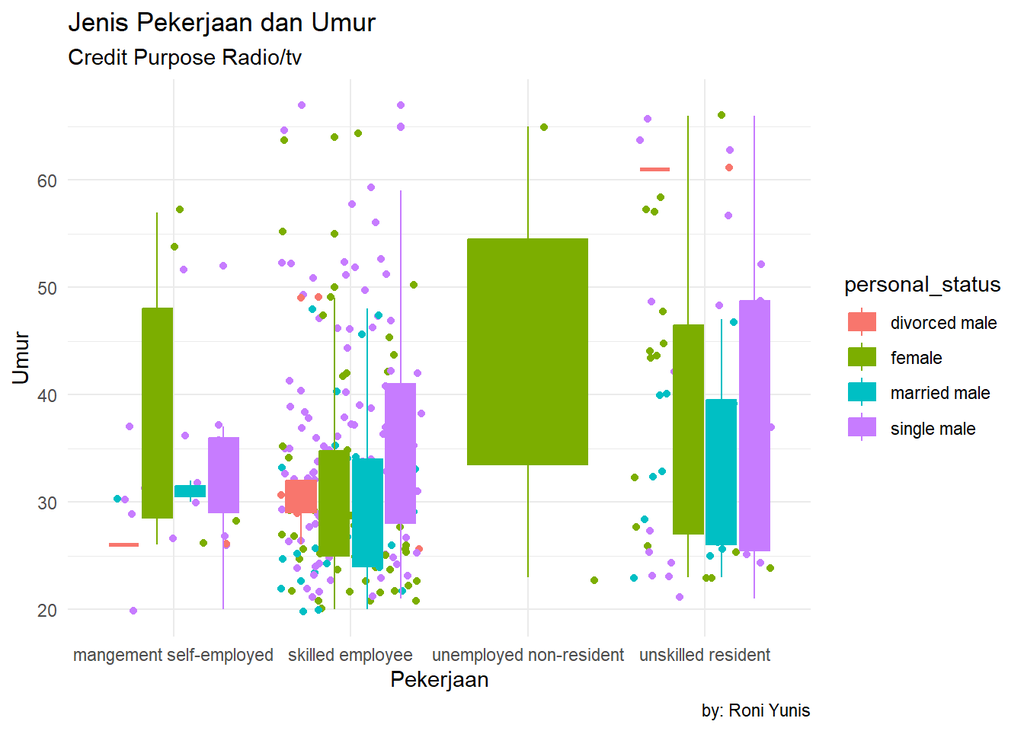

```r
# Visualisasi yang mengajukan credit dengan tujuan radio/tv dilihat dari umur dan jenis pekerjaan
radiotv %>%
  ggplot(aes(x=job, y=age, col=personal_status, fill=personal_status)) +
  geom_jitter() +
  geom_boxplot() +
  labs(
    title = "Jenis Pekerjaan dan Umur",
    subtitle = "Credit Purpose Radio/tv",
    caption = "by: Roni Yunis",
    x = "Pekerjaan",
    y = "Umur"
  ) +
  theme_minimal()
```

# Membagi Dataset

```r
set.seed(100) #pengambilan data secara random
#untuk data training diambil 70%, sisanya untuk data testing, berdasarkan variabel foreign_worker
index_train <- createDataPartition(credit$foreign_worker,
                                   p = 0.7,list = FALSE)

data.train <- credit[index_train,] # 70% untuk data training
data.test <- credit[-index_train,] # sisanya atau 30% untuk data testing
```

```r
dim(data.train)
```

```
## [1] 701  21
```

```r
dim(data.test)
```

```
## [1] 299  21
```

Setelah kita bagi, maka bisa dijelaskan bahwa untuk data training ada 701 baris data dan untuk data testing ada 299 baris data yang kita gunakan utk mendukung klasifikasikan yang akan dilakukan.

# Model Klasifikasi dengan Decision Tree

## Memodelkan klasifikasi

```r
modelTree <- rpart(data=data.train,
               foreign_worker~.,
               control = rpart.control(cp=0, minsplit=15))
```

opsi minsplit = 15 memgandung pengertian bahwa jika ada node yang berukuran kurang dari 15, maka algoritma dihentikan

```r
modelTree
```

```
## n= 701
##
## node), split, n, loss, yval, (yprob)
##       * denotes terminal node
##
##  1) root 701 26 yes (0.03708987 0.96291013)
##    2) months_loan_duration< 10.5 122 16 yes (0.13114754 0.86885246)
##      4) purpose=car (new),repairs 43 10 yes (0.23255814 0.76744186)
##        8) telephone=none 27 10 yes (0.37037037 0.62962963)
##         16) amount< 1427.5 17  8 no (0.52941176 0.47058824)
##           32) age>=33.5 8  1 no (0.87500000 0.12500000) *
##           33) age< 33.5 9  2 yes (0.22222222 0.77777778) *
##         17) amount>=1427.5 10  1 yes (0.10000000 0.90000000) *
##        9) telephone=yes 16  0 yes (0.00000000 1.00000000) *
##      5) purpose=business,car (used),domestic appliances,education,furniture,others,radio/tv,retraining 79  6 yes (0.07594937 0.92405063) *
##    3) months_loan_duration>=10.5 579 10 yes (0.01727116 0.98272884) *
```

## Visualisasi Model Klasifikasi

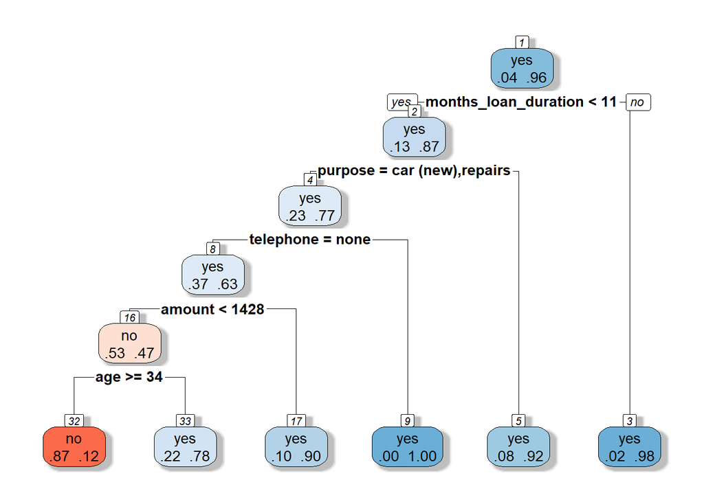

```r
# Menampikan pohon klasifikasi
rpart.plot(modelTree, extra=4,box.palette="RdBu", shadow.col="gray", nn=TRUE)
```

## Mengukur Kinerja Prediksi

```r
prediksiTree <- predict(modelTree, data.test)
head(prediksiTree, n=10)
```

```
##            no       yes
## 3  0.01727116 0.9827288
## 5  0.01727116 0.9827288
## 7  0.01727116 0.9827288
## 8  0.01727116 0.9827288
## 17 0.01727116 0.9827288
## 20 0.01727116 0.9827288
## 22 0.07594937 0.9240506
## 23 0.10000000 0.9000000
## 27 0.07594937 0.9240506
## 31 0.01727116 0.9827288
```

```r
prediksi.status.t <- ifelse(prediksiTree[,2] > 0.5, "yes", "no")
#menghitung ukuran kinerja prediksi
confusionMatrix(as.factor(prediksi.status.t), as.factor(data.test$foreign_worker))
```

```
## Confusion Matrix and Statistics
##
##           Reference
## Prediction  no yes
##        no    1   3
##        yes  10 285
##
##                Accuracy : 0.9565
##                  95% CI : (0.9268, 0.9766)
##     No Information Rate : 0.9632
##     P-Value [Acc > NIR] : 0.78480
##
##                   Kappa : 0.116
##
##  Mcnemar's Test P-Value : 0.09609
##
##             Sensitivity : 0.090909
##             Specificity : 0.989583
##          Pos Pred Value : 0.250000
##          Neg Pred Value : 0.966102
##              Prevalence : 0.036789
##          Detection Rate : 0.003344
##    Detection Prevalence : 0.013378
##       Balanced Accuracy : 0.540246
##
##        'Positive' Class : no
##
```

Berdasarkan hasil diatas bisa lihat bahwa nilai akurasi sebesar 95,6%

## Hitung Nilai Performance dari Prediksi

Kurva ini digunakan untuk menilai hasil prediksi

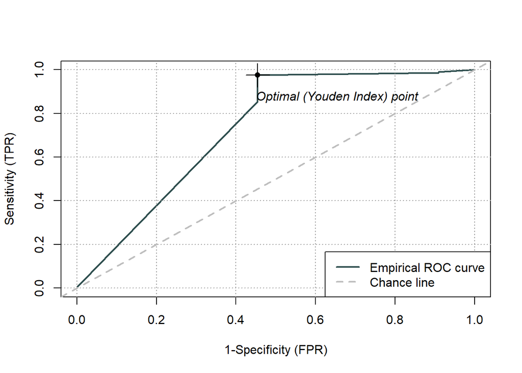

```r
ngitungROCt <- rocit(score=prediksiTree[,2],class=data.test$foreign_worker)
plot(ngitungROCt)
```

Setelah didapatkan nilai curva, maka langkah selanjutnya adalah menghitung Area Under Curve (AUC) yang nantinya dijadikan sebagai dasar untuk menentukan ketepatan prediksi klasifikasi yang sudah lakukan. Nilai AUC bisa dikelompokkan atas: a. 0.90 - 1.00 = Exellence Classification b. 0.80 - 0.90 = Good Classification c. 0.70 - 0.80 = Fair Classification d. 0.60 - 0.70 = Poor Classification e. 0.50 - 0.60 = Failur

Dalam banyak kasus, nilai AUC ini juga digunakan untuk mengukur perbedaan performansi metode klasifikasi.

```r
ngitungROCt
```

```
##
##  Method used: empirical
##  ===== Positive(s) =====
##  Number of positive(s): 288
##  Mean of positive(s): 0.9651
##  Variance of positive(s): 0.008019
##  ===== Negative(s) =====
##  Number of negative(s): 11
##  Mean of negative(s): 0.8671
##  Variance of negative(s): 0.0623
##  ===== AUC =====
##  Area under curve: 0.7312
##
##  =========================
##     FPR      TPR
##  0.0000 0.000000
##  0.0000 0.003472
##  0.4545 0.854167
##  0.4545 0.975694
##  0.9091 0.986111
##  0.9091 0.989583
##  1.0000 1.000000
```

```r
# Menghitung Area Under Curve (AUC)
AUCtree <- ngitungROCt$AUC
AUCtree
```

```
## [1] 0.7312184
```

Nilai AUC nya adalah 73,1%, artinya klasifikasi yang dihasilkan termasuk pada **fair classification**

# Model Klasifikasi dengan Random Forest

## Memodelkan klasifikasi

```r
set.seed(123) #menentukan nilai acak dari data
modelForest <- randomForest(data=data.train,
               as.factor(foreign_worker)~.,
               ntree=100, mtry=3)
```

```r
modelForest
```

```
##
## Call:
##  randomForest(formula = as.factor(foreign_worker) ~ ., data = data.train,      ntree = 100, mtry = 3)
##                Type of random forest: classification
##                      Number of trees: 100
## No. of variables tried at each split: 3
##
##         OOB estimate of  error rate: 3.71%
## Confusion matrix:
##     no yes class.error
## no   0  26           1
## yes  0 675           0
```

Tingkat kesalahan sebesar 3,71% atau dengan akurasi sebesar 96,29%

## Mengukur kinerja prediksi

```r
hasilPrediksi <- predict(modelForest, data.test, type="prob")
head(hasilPrediksi, n=10)
```

```
##      no  yes
## 3  0.03 0.97
## 5  0.02 0.98
## 7  0.01 0.99
## 8  0.00 1.00
## 17 0.00 1.00
## 20 0.00 1.00
## 22 0.08 0.92
## 23 0.40 0.60
## 27 0.06 0.94
## 31 0.00 1.00
```

## Menampilkan plot hasil prediksi

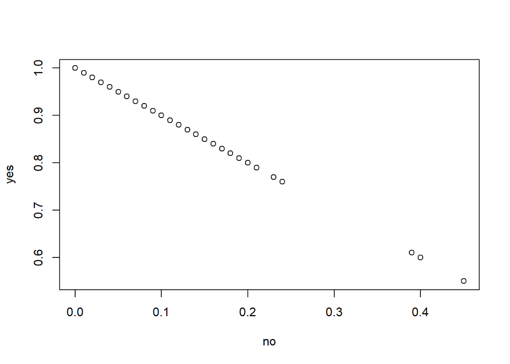

```r
plot(hasilPrediksi )
```

```r
prediksi.status.f <- ifelse(hasilPrediksi[,2] > 0.5, "yes", "no")

#menghitung ukuran kinerja prediksi
confusionMatrix(as.factor(prediksi.status.f), as.factor(data.test$foreign_worker))
```

```
## Confusion Matrix and Statistics
##
##           Reference
## Prediction  no yes
##        no    0   0
##        yes  11 288
##
##                Accuracy : 0.9632
##                  95% CI : (0.9351, 0.9815)
##     No Information Rate : 0.9632
##     P-Value [Acc > NIR] : 0.579281
##
##                   Kappa : 0
##
##  Mcnemar's Test P-Value : 0.002569
##
##             Sensitivity : 0.00000
##             Specificity : 1.00000
##          Pos Pred Value :     NaN
##          Neg Pred Value : 0.96321
##              Prevalence : 0.03679
##          Detection Rate : 0.00000
##    Detection Prevalence : 0.00000
##       Balanced Accuracy : 0.50000
##
##        'Positive' Class : no
##
```

Berdasarkan hasil diatas bisa lihat bahwa nilai akurasi sebesar 96,3 %

## Hitung Nilai Performance dari Prediksi

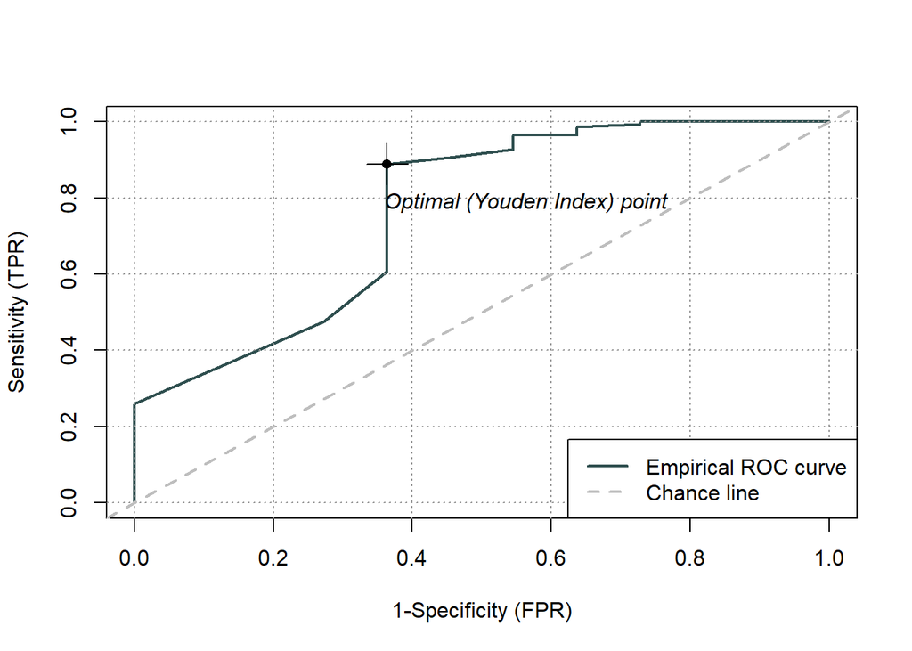

```r
ngitungROCf <- rocit(score=hasilPrediksi[,2],class=data.test$foreign_worker)
plot(ngitungROCf)
```

```r
AUCf <- ngitungROCf$AUC
AUCf
```

```
## [1] 0.7649937
```

Nilai AUC nya adalah 76,5%, artinya klasifikasi yang dihasilkan termasuk pada **fair classification**

Kalau kita bandingkan dari kedua model tersebut, kinerja dari klasifikasi dengan *Random Forest* **lebih baik sedikit** dibandingkan dengan *Decision Tree*